# Old Faithful Geyser Eruption Cycle

5/28/2020

## Yellowstone National Park : Old Faithful Geyser

Old Faithful Geyser, which is part of the Yellow Stone National Park, has been documented to erupt at a regular rate, and predicted to be the most reliable among its peers of other big geysers. It is not the biggest or the most regular geyser in Yellowstone National Park, however, it is the most famous. In fact, it is believed that its regularity is does not correlate to any other hydrothermal features within the Yellow Stone Park sector.

To learn more, see [Old Faithful Geyser](https://www.nps.gov/places/old-faithful-geyser.htm).

## Old Faithful Geyser

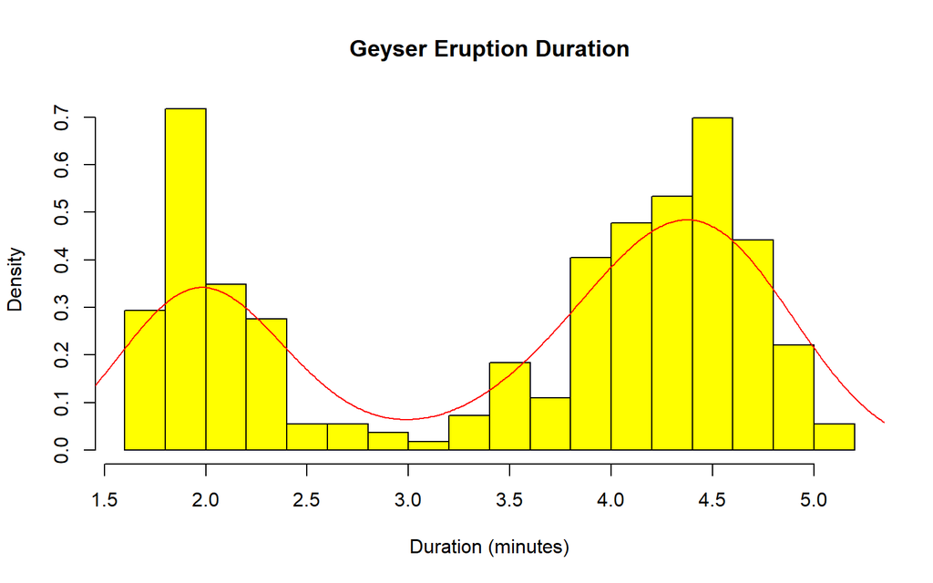

## Facts: Old Faithful Geyser

- average interval between eruptions is about 90 minutes
- erruptions vary from 50 to 127 minute
- eruption lasts 1.5 to 5 minutes
- eruptions expel between 3,700–8,400 gallons of boiling water
- on average, eruptions reach a height of 106–184 feet
- average eruption temperature of 169.7°F (76.5°C)
- an average pH of 9
- an average conductivity of 1972 uS/cm

## Old Faithful Summary Statistics

Eruption Frequency & Regression Eruption Duration Summary Statistics that depict the average wait time for an eruption as well as the average duration of an eruption when it occurs, in minutes.

```r
summary(faithful)
```

```
##    eruptions        waiting
##  Min.   :1.600   Min.   :43.0
##  1st Qu.:2.163   1st Qu.:58.0
##  Median :4.000   Median :76.0
##  Mean   :3.488   Mean   :70.9
##  3rd Qu.:4.454   3rd Qu.:82.0
##  Max.   :5.100   Max.   :96.0
```